# Experimentos TFM

Carolina Mulet

2024-06-04

# Experimento 1

Quiero ver qué pasa cuando aumento el número de grupos falsos, manteniendo el mismo número de variables en cada grupo (4). Los datos los genero con:

$\theta = 1 + \beta_1X_1+\beta_2X_2$, $\pi=\frac{e^{\theta}}{1 + e^{\theta}}$ e $Y\sim Ber(\pi)$.

Con $\beta_1=(-0.6, -0.56, -0.53, 0.49)$ y $\beta_2=(-0.45, 0.4, 0.35, 0.3)$.

### Grupos

En general:

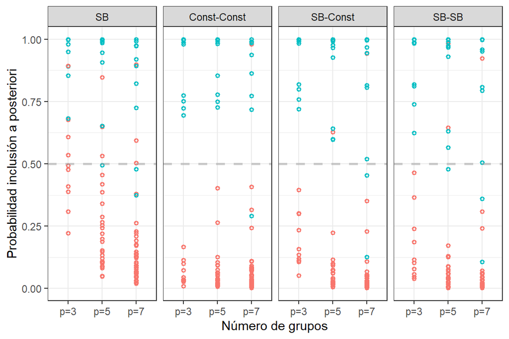

En función del número de grupos:

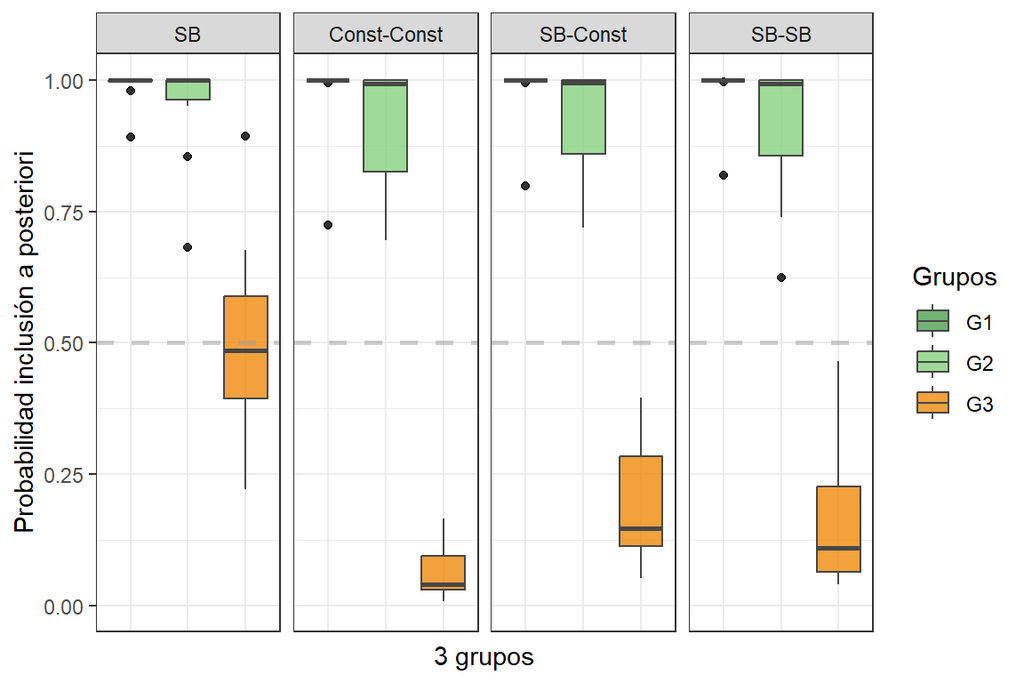

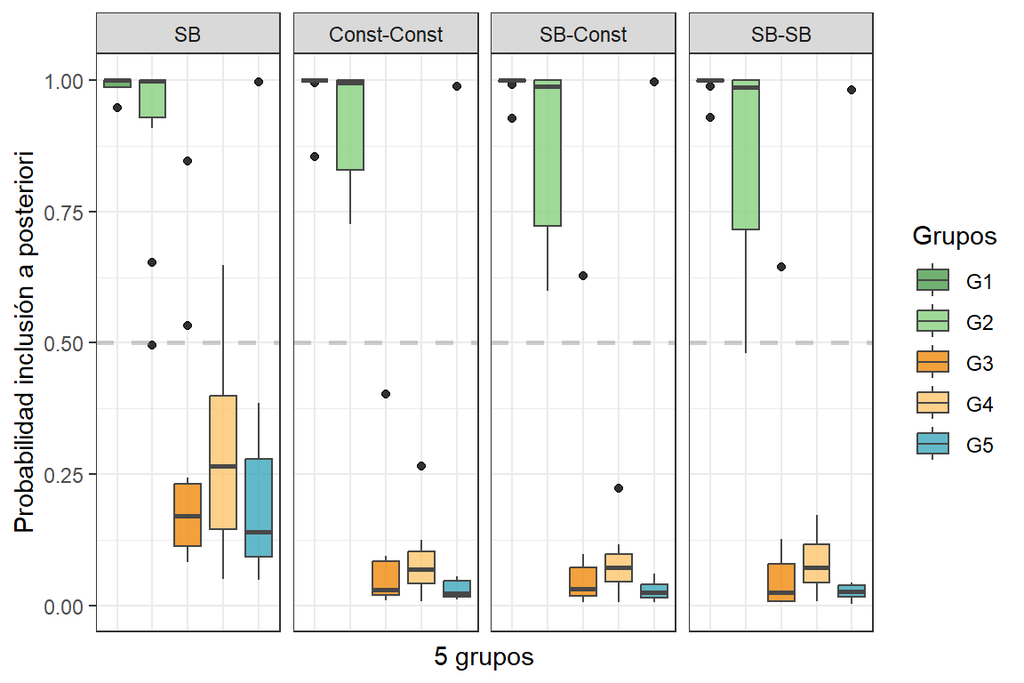

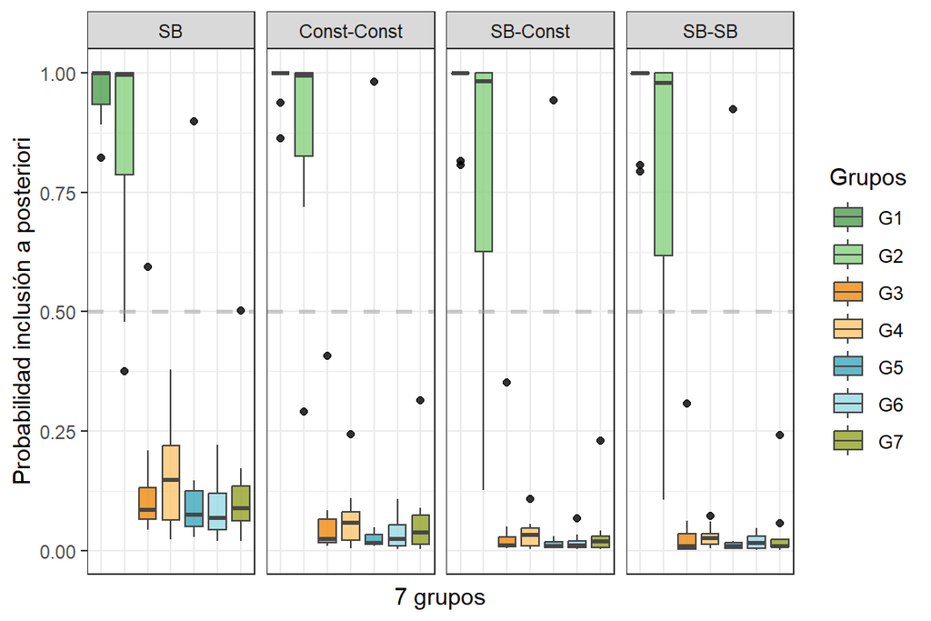

Porcentaje de grupos incorrectos:

Porcentaje de grupos incorrectamente seleccionados para cada previa elegida.

|  | SB | Const-Const | SB-Const | SB-SB |
| --- | --- | --- | --- | --- |
| p=3 | 40% | 0% | 0% | 0% |
| p=5 | 13.3333333333333% | 3.33333333333333% | 6.66666666666667% | 6.66666666666667% |
| p=7 | 6% | 2% | 2% | 2% |

Porcentaje de grupos incorrectamente no seleccionados para cada previa elegida.

|  | SB | Const-Const | SB-Const | SB-SB |
| --- | --- | --- | --- | --- |
| p=3 | 0% | 0% | 0% | 0% |
| p=5 | 5% | 0% | 0% | 5% |
| p=7 | 10% | 5% | 10% | 10% |

### Variables agrupadas verdaderas (de G1 y G2)

En general:

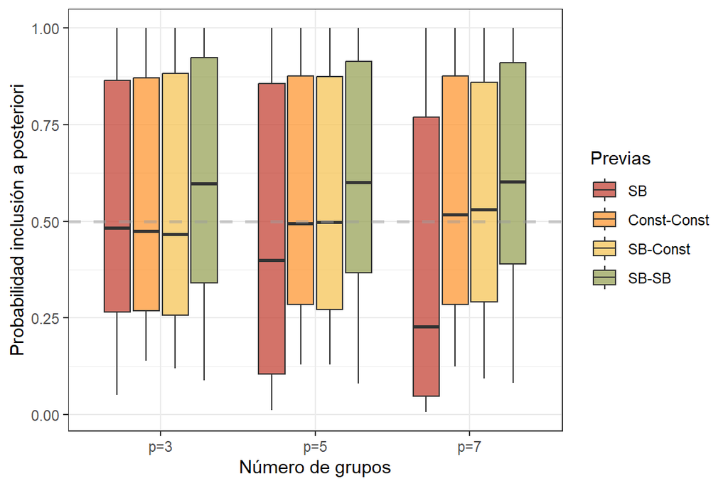

En función del número de grupos:

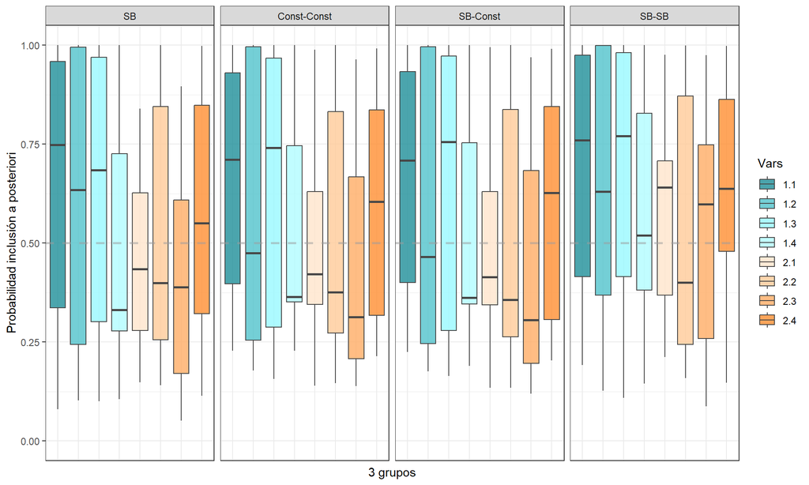

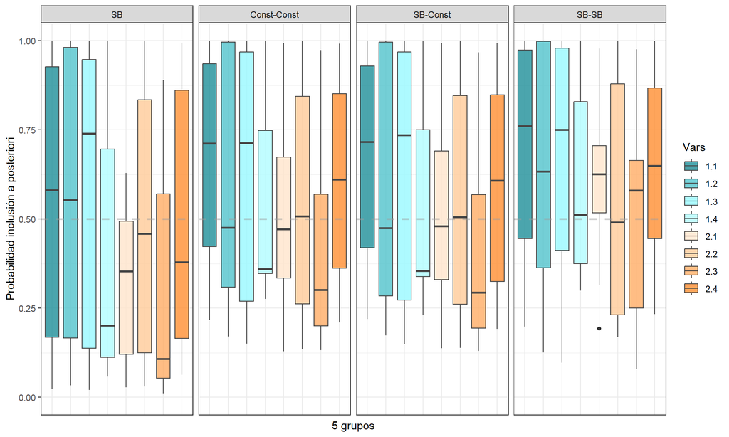

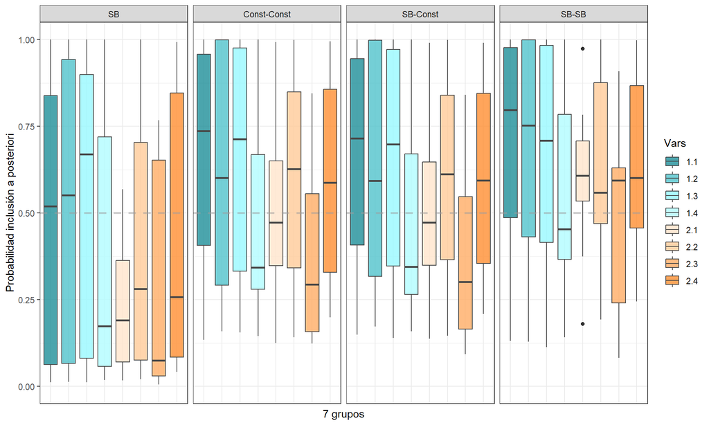

Variables agrupadas incorrectamente no seleccionadas de los 2 primeros grupos:

Porcentaje de variables agrupadas incorrectamente no seleccionadas para SB.

|  | G1 | G2 |
| --- | --- | --- |
| p=3 | 47.5% | 57.5% |
| p=5 | 52.5% | 60% |
| p=7 | 52.5% | 67.5% |

Porcentaje de variables agrupadas incorrectamente no seleccionadas para Const-Const.

|  | G1 | G2 |
| --- | --- | --- |
| p=3 | 47.5% | 55% |
| p=5 | 47.5% | 52.5% |
| p=7 | 47.5% | 50% |

Porcentaje de variables agrupadas incorrectamente no seleccionadas para SB-Const.

|  | G1 | G2 |
| --- | --- | --- |
| p=3 | 47.5% | 55% |
| p=5 | 47.5% | 52.5% |
| p=7 | 47.5% | 50% |

Porcentaje de variables agrupadas incorrectamente no seleccionadas para SB-SB.

|  | G1 | G2 |
| --- | --- | --- |
| p=3 | 40% | 42.5% |
| p=5 | 37.5% | 37.5% |
| p=7 | 35% | 37.5% |

# Experimento 2.1: Añadir 3, 8 y 13 variables agrupadas falsas

Quiero ver qué pasa cuando aumento el número de variables falsas en cada grupo, manteniendo el mismo número de grupos, 4. Los datos los genero con:

$\theta = 1 + \beta_1X_1$, $\pi=\frac{e^{\theta}}{1 + e^{\theta}}$ e $Y\sim Ber(\pi)$.

El primer grupo solo con las dos primeras variables verdaderas. Y luego añado 3 grupos falsos más. Lo hago con 5, 10 y 15 variables cada uno.

Con $\beta_{11} = 0.56$ y $\beta_{12} = 0.49$.

### Grupos

En general:

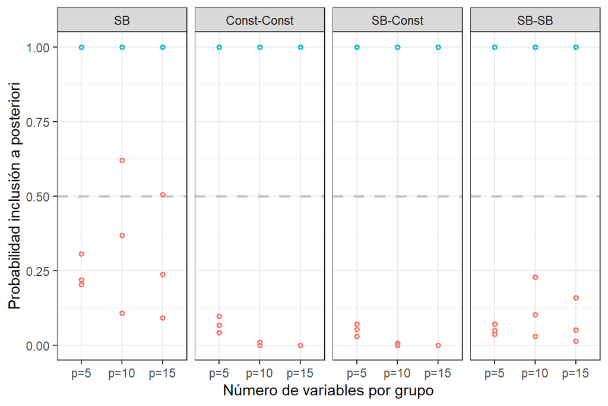

En función del número de variables en cada grupo:

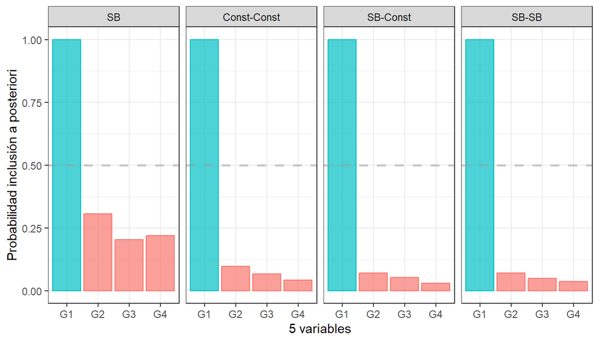

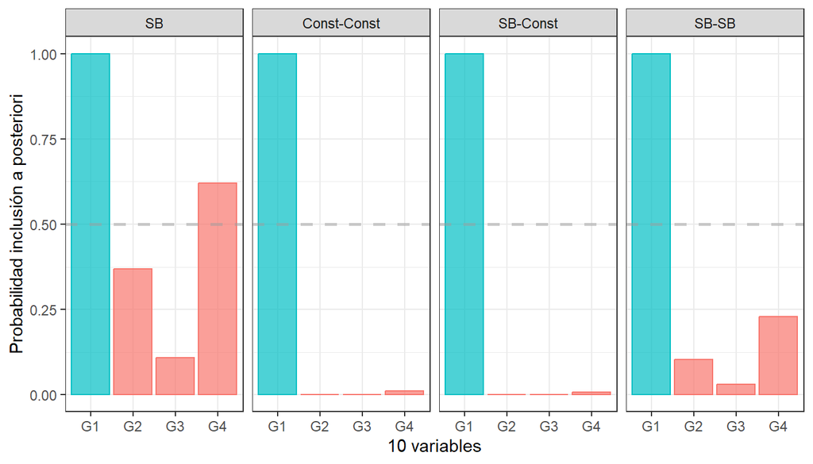

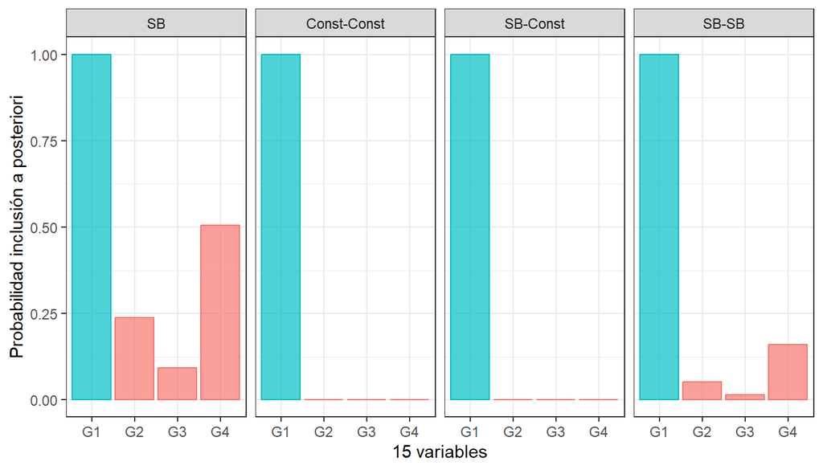

Probabilidad de inclusión a posteriori para cada grupo:

Probabilidad para cada grupo según el número de variables con SB.

|  | G1 | G2 | G3 | G4 |
| --- | --- | --- | --- | --- |
| p=5 | 1 | 0.31 | 0.20 | 0.22 |
| p=10 | 1 | 0.37 | 0.11 | 0.62 |
| p=15 | 1 | 0.24 | 0.09 | 0.50 |

Probabilidad para cada grupo según el número de variables con Const-Const.

|  | G1 | G2 | G3 | G4 |
| --- | --- | --- | --- | --- |
| p=5 | 1 | 0.1 | 0.07 | 0.04 |
| p=10 | 1 | 0.0 | 0.00 | 0.01 |
| p=15 | 1 | 0.0 | 0.00 | 0.00 |

Probabilidad para cada grupo según el número de variables con SB-Const.

|  | G1 | G2 | G3 | G4 |
| --- | --- | --- | --- | --- |
| p=5 | 1 | 0.07 | 0.05 | 0.03 |
| p=10 | 1 | 0.00 | 0.00 | 0.01 |
| p=15 | 1 | 0.00 | 0.00 | 0.00 |

Probabilidad para cada grupo según el número de variables con SB-SB.

|  | G1 | G2 | G3 | G4 |
| --- | --- | --- | --- | --- |
| p=5 | 1 | 0.07 | 0.05 | 0.04 |
| p=10 | 1 | 0.10 | 0.03 | 0.23 |
| p=15 | 1 | 0.05 | 0.01 | 0.16 |

### Variables agrupadas

En general:

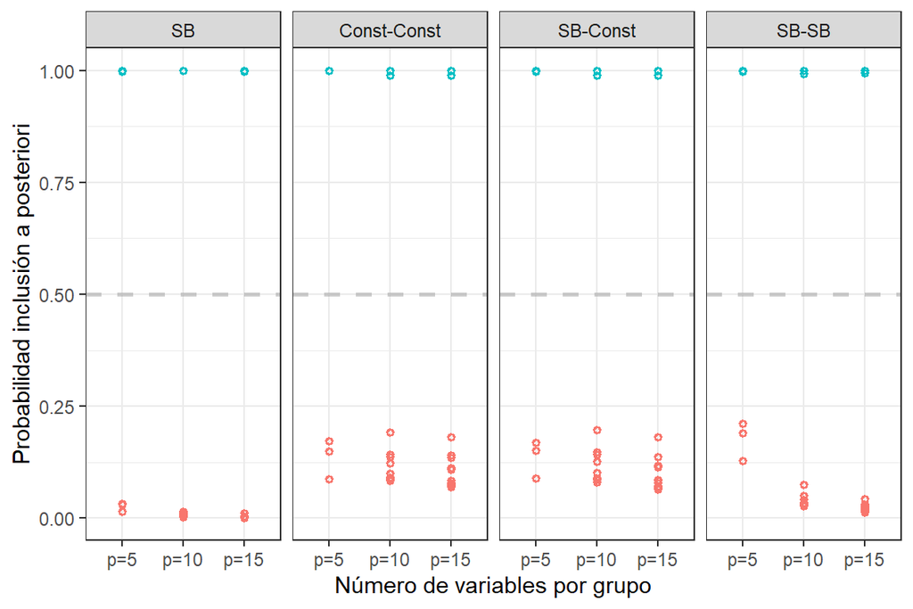

En función del número de variables en cada grupo:

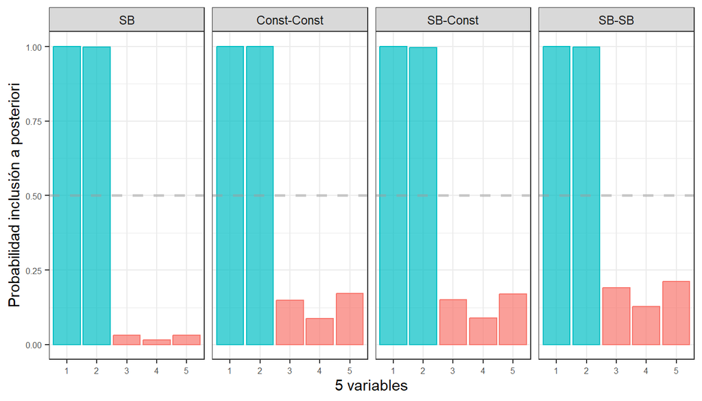

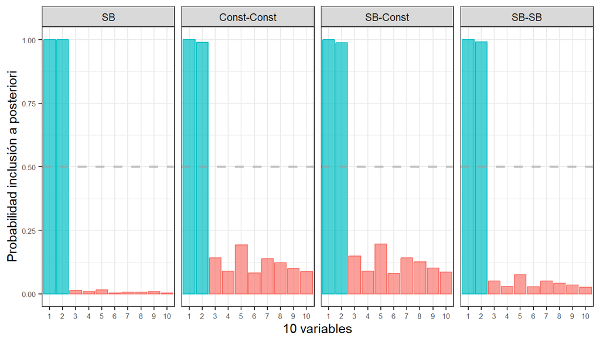

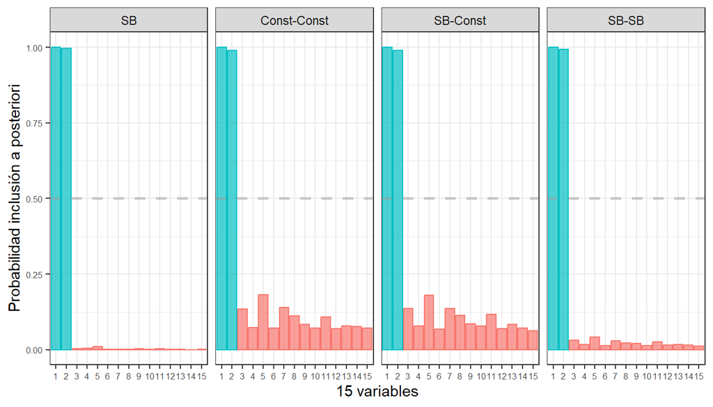

Con $\beta_{11} = -0.43$ y $\beta_{12} = -0.37$.

### Grupos

En general:

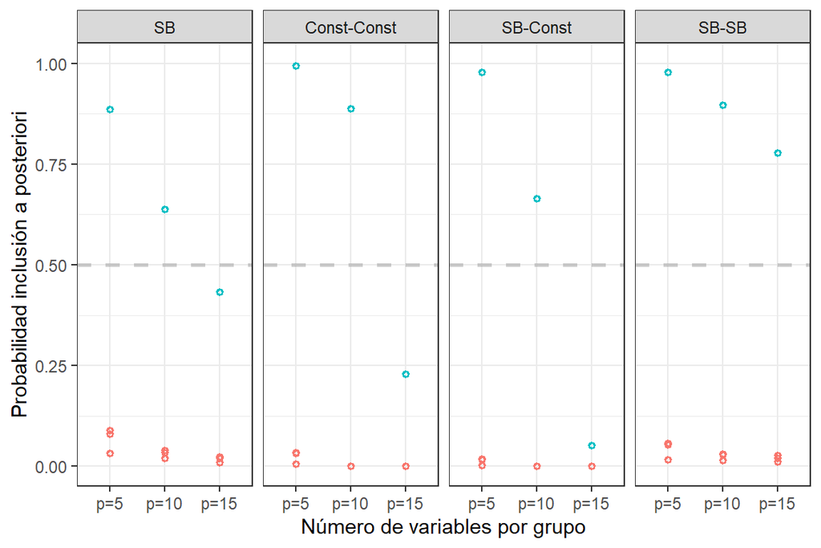

En función del número de variables en cada grupo:

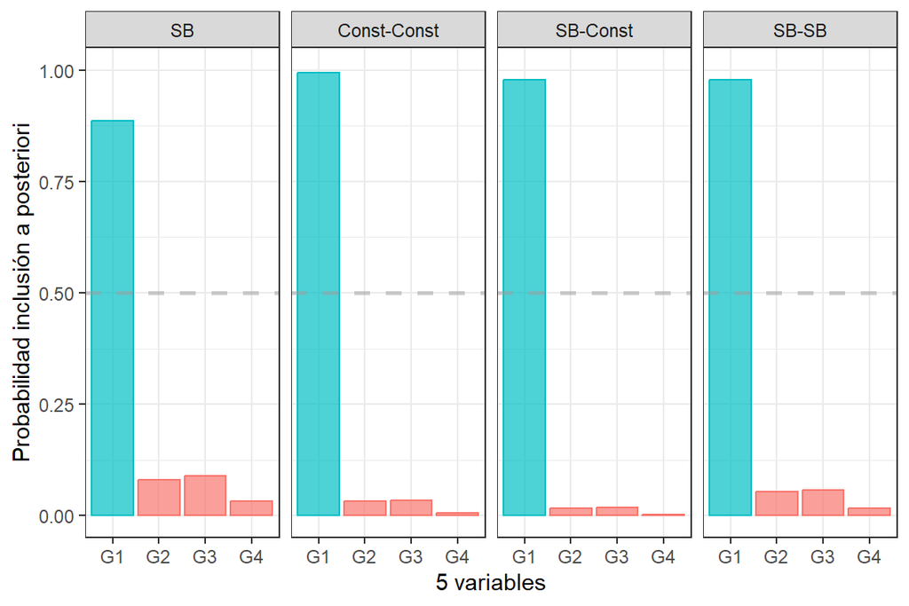

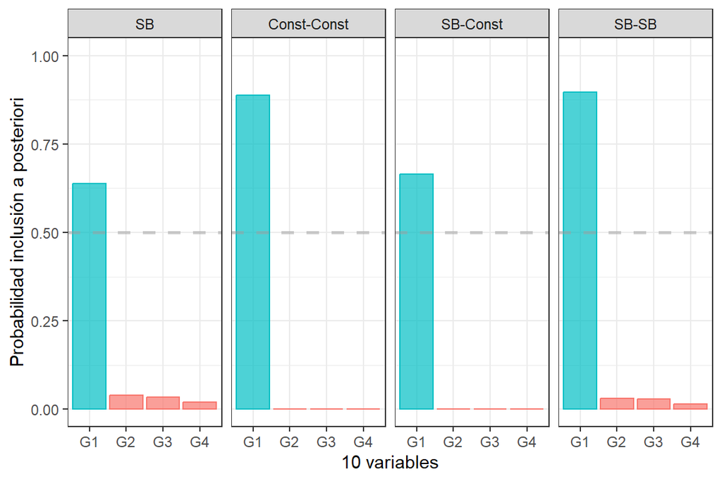

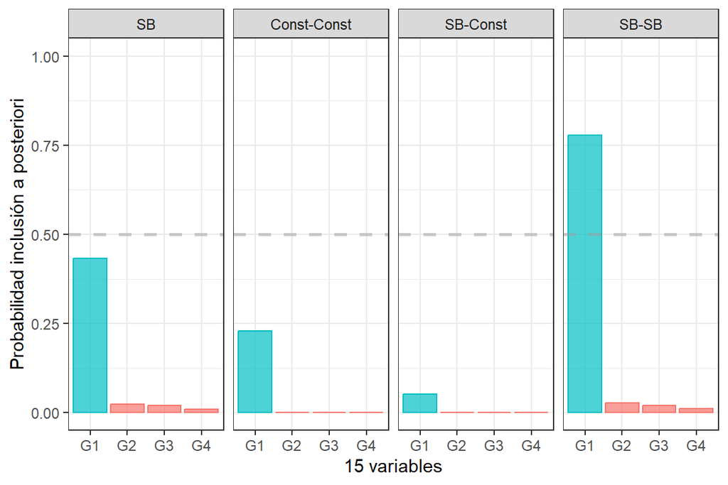

Probabilidad de inclusión a posteriori para cada grupo:

Probabilidad para cada grupo según el número de variables con SB.

|  | G1 | G2 | G3 | G4 |
| --- | --- | --- | --- | --- |
| p=5 | 0.89 | 0.08 | 0.09 | 0.03 |
| p=10 | 0.64 | 0.04 | 0.03 | 0.02 |
| p=15 | 0.43 | 0.02 | 0.02 | 0.01 |

Probabilidad para cada grupo según el número de variables con Const-Const.

|  | G1 | G2 | G3 | G4 |
| --- | --- | --- | --- | --- |
| p=5 | 0.99 | 0.03 | 0.03 | 0.01 |
| p=10 | 0.89 | 0.00 | 0.00 | 0.00 |
| p=15 | 0.23 | 0.00 | 0.00 | 0.00 |

Probabilidad para cada grupo según el número de variables con SB-Const.

|  | G1 | G2 | G3 | G4 |
| --- | --- | --- | --- | --- |
| p=5 | 0.98 | 0.02 | 0.02 | 0 |
| p=10 | 0.67 | 0.00 | 0.00 | 0 |
| p=15 | 0.05 | 0.00 | 0.00 | 0 |

Probabilidad para cada grupo según el número de variables con SB-SB.

|  | G1 | G2 | G3 | G4 |
| --- | --- | --- | --- | --- |
| p=5 | 0.98 | 0.05 | 0.06 | 0.02 |
| p=10 | 0.90 | 0.03 | 0.03 | 0.01 |
| p=15 | 0.78 | 0.03 | 0.02 | 0.01 |

### Variables agrupadas

En general:

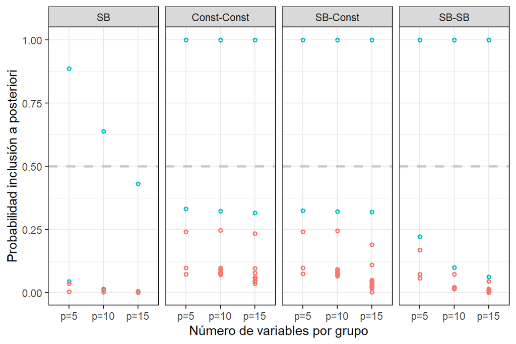

En función del número de variables en cada grupo:

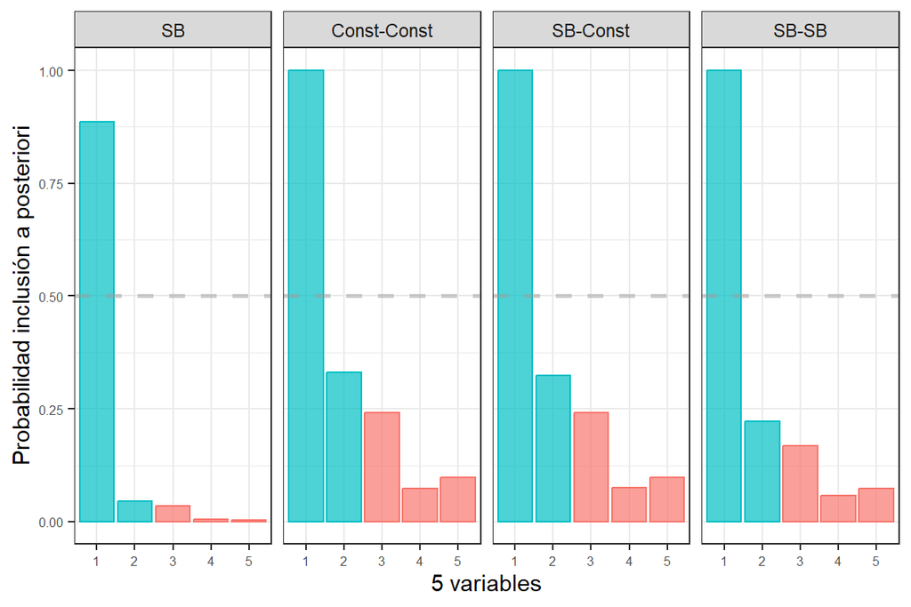

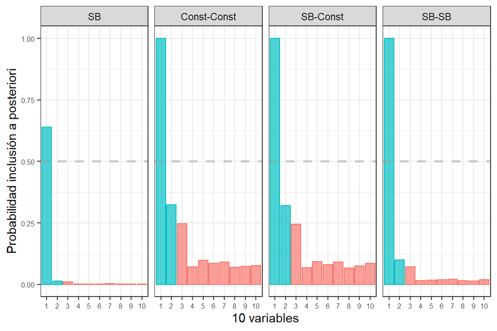

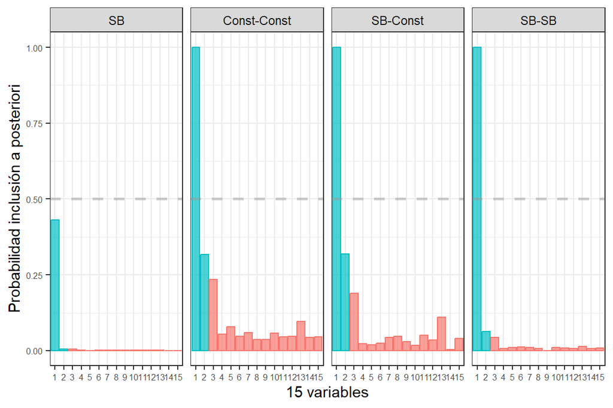

# Experimento 2.2: 5, 10 y 15 variables agrupadas verdaderas

Quiero ver qué pasa cuando aumento el número de variables que generan los datos en cada grupo, manteniendo el mismo número de grupos, 4. Los datos los genero con:

$\theta = 1 + \beta_1X_1$, $\pi=\frac{e^{\theta}}{1 + e^{\theta}}$ e $Y\sim Ber(\pi)$. Todas las variables del primer grupo generan los datos.

Y luego añado 3 grupos falsos más. Lo repito con 5, 10 y 15 variables cada uno.

Con 5 variables: $\beta_1 = (0.63, 0.58, -0.53, 0.5, -0.46)$.

Con 10 variables: $\beta_1 = (0.63, 0.58, -0.53, 0.5, -0.46, 0.63, 0.58, -0.53, 0.5, -0.46)$.

Con 15 variables: $\beta_1 = c(0.63, 0.58, -0.53, 0.5, -0.46, 0.63, 0.58, -0.53, 0.5, -0.46, 0.63, 0.58, -0.53, 0.5, -0.46)$.

### Grupos

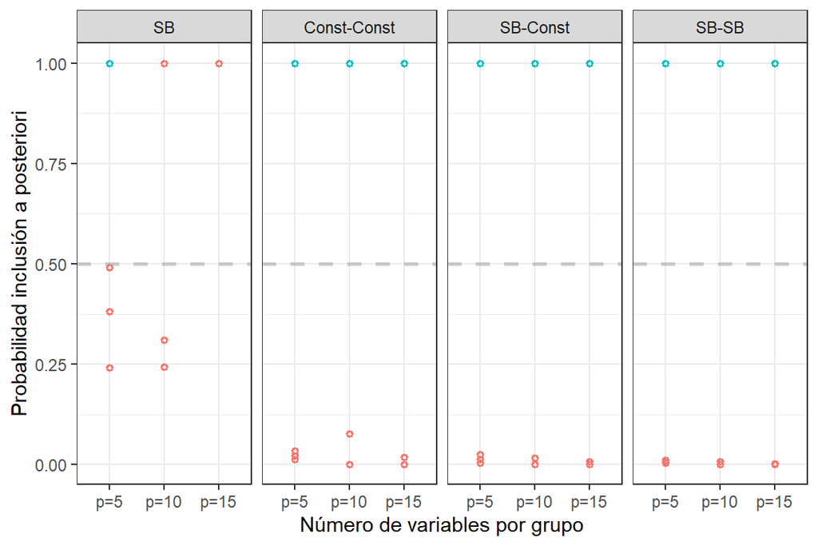

En función del número de variables en cada grupo:

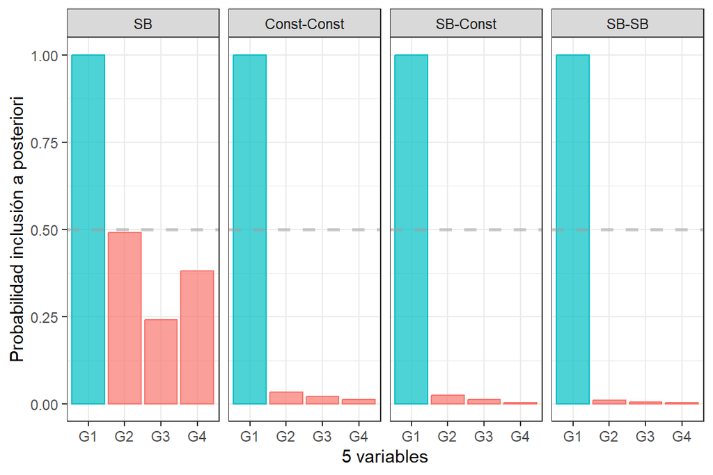

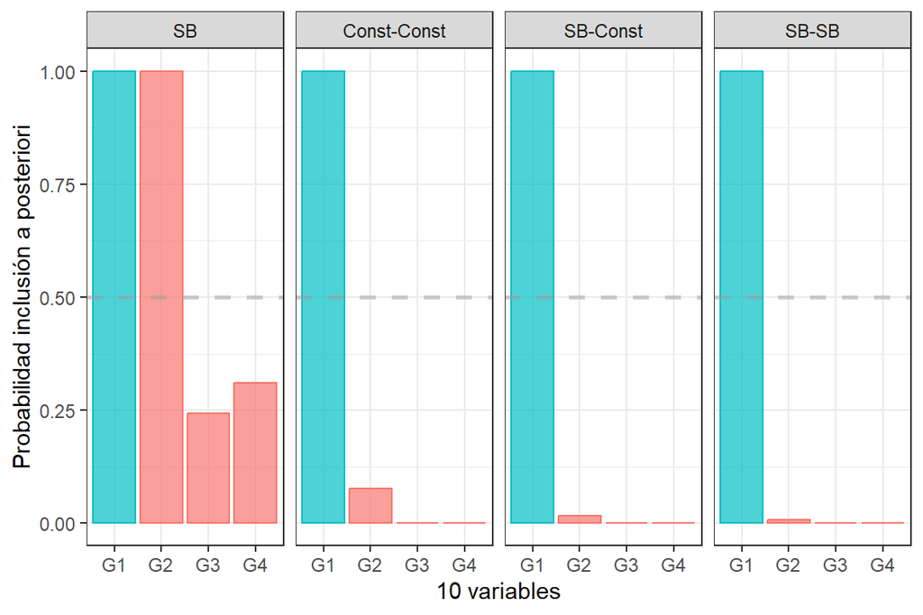

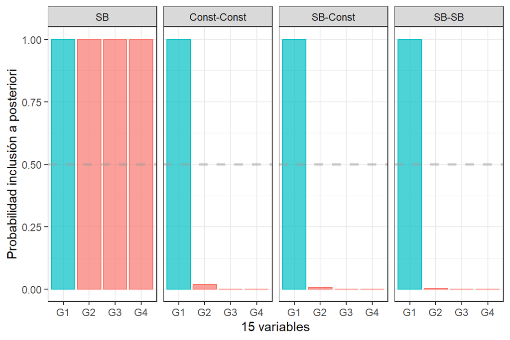

Probabilidad para cada grupo según el número de variables con SB.

|  | G1 | G2 | G3 | G4 |
| --- | --- | --- | --- | --- |
| p=5 | 1 | 0.49 | 0.24 | 0.38 |
| p=10 | 1 | 1.00 | 0.24 | 0.31 |
| p=15 | 1 | 1.00 | 1.00 | 1.00 |

Probabilidad para cada grupo según el número de variables con Const-Const.

|  | G1 | G2 | G3 | G4 |
| --- | --- | --- | --- | --- |
| p=5 | 1 | 0.03 | 0.02 | 0.01 |
| p=10 | 1 | 0.08 | 0.00 | 0.00 |
| p=15 | 1 | 0.02 | 0.00 | 0.00 |

Probabilidad para cada grupo según el número de variables con SB-Const.

|  | G1 | G2 | G3 | G4 |
| --- | --- | --- | --- | --- |
| p=5 | 1 | 0.02 | 0.01 | 0 |
| p=10 | 1 | 0.02 | 0.00 | 0 |
| p=15 | 1 | 0.01 | 0.00 | 0 |

Probabilidad para cada grupo según el número de variables con SB-SB.

|  | G1 | G2 | G3 | G4 |
| --- | --- | --- | --- | --- |
| p=5 | 1 | 0.01 | 0.01 | 0 |
| p=10 | 1 | 0.01 | 0.00 | 0 |
| p=15 | 1 | 0.00 | 0.00 | 0 |

### Variables agrupadas verdaderas (G1)

En general:

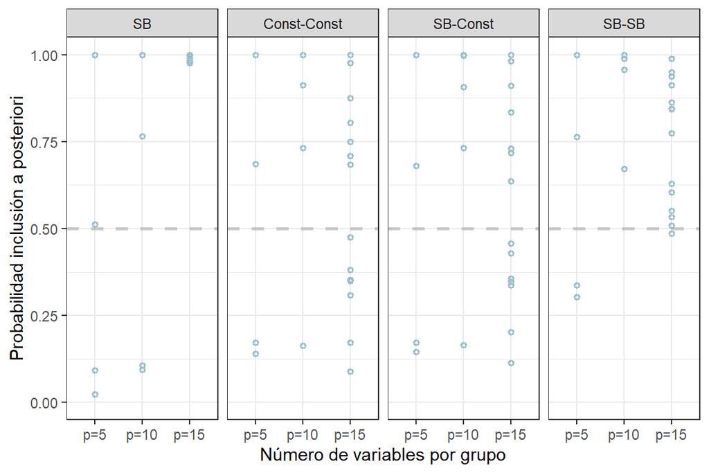

En función del número de variables en cada grupo:

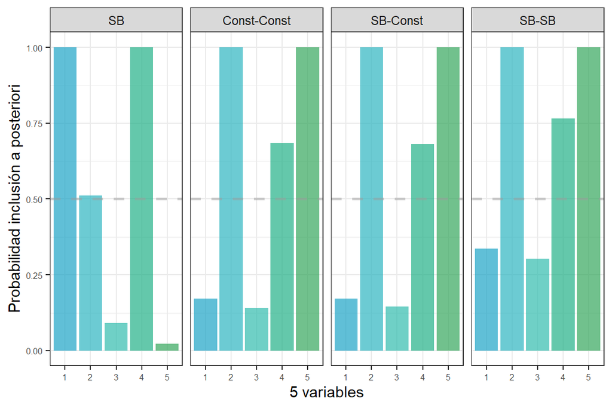

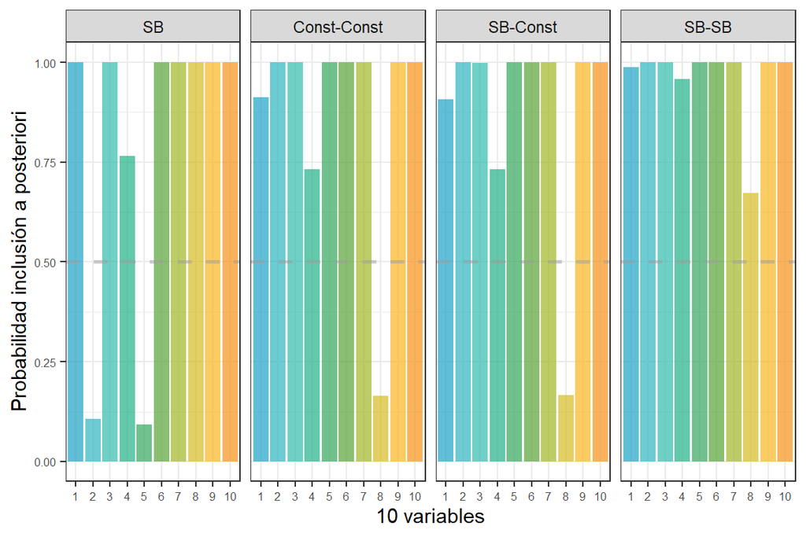

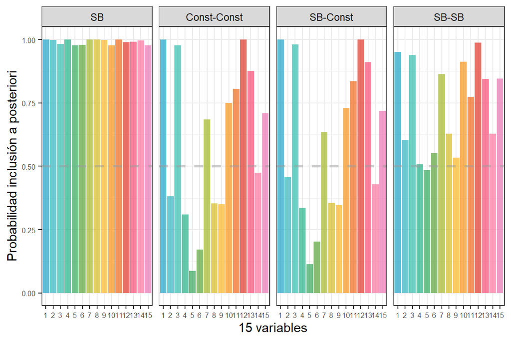

Con 5 variables: $\beta_1 = (-0.41, 0.39, -0.35, 0.3, 0.27)$.

Con 10 variables: $\beta_1 = (-0.41, 0.39, -0.35, 0.3, 0.27, -0.41, 0.39, -0.35, 0.3, 0.27)$.

Con 15 variables: $\beta_1 = (-0.41, 0.39, -0.35, 0.3, 0.27, -0.41, 0.39, -0.35, 0.3, 0.27, -0.41, 0.39, -0.35, 0.3, 0.27)$.